# R bootcamp, Module 6: Programming

August 2014, UC Berkeley

Chris Paciorek/Jarrod Millman

# When do I start programming?

> “[W]e wanted users to be able to begin in an interactive environment, where they did not consciously think of themselves as programming. Then as their needs became clearer and their sophistication increased, they should be able **to slide gradually into programming, when the language and system aspects would become more important**.”

[John Chambers, “Stages in the Evolution of S”](http://www.stat.bell-labs.com/S/history.html)

### Acknowledgement

[Advanced R](http://adv-r.had.co.nz/) by Hadley Wickham.

# Key Principles

- Everything that exists is an object.
- Everything that happens is a function call.

[John Chambers' useR!2014 talk](http://user2014.stat.ucla.edu/files/chambers.pdf)

### What does the 2nd principle mean?

Are arithmetic operations really just functions?

```r
3+2
```

```
## [1] 5
```

```r
'+'(3,2)
```

```
## [1] 5
```

What about indexing?

```r
x=matrix(runif(100),10)
x[,2]
```

```
##  [1] 0.73913 0.88434 0.92706 0.20638 0.54049 0.05107 0.37316 0.18609
##  [9] 0.98317 0.87664
```

```r
'['(x,,2)
```

```
##  [1] 0.73913 0.88434 0.92706 0.20638 0.54049 0.05107 0.37316 0.18609
##  [9] 0.98317 0.87664
```

### What does the 1st principle mean?

```r
class(1)
```

```
## [1] "numeric"
```

```r
class(runif)
```

```
## [1] "function"
```

```r
class(function(x) x^2)
```

```
## [1] "function"
```

```r
square = function(x) x^2
class(square)
```

```
## [1] "function"
```

# So what is a function in R?

You've been working with functions for at least a day now and you've probably started to get an informal feel for them. Now it is time to make those informal notions more precise.

> In computer programming, a subroutine is **a sequence of program instructions that perform a specific task, packaged as a unit**. This unit can then be used in programs wherever that particular task should be performed. Subprograms may be defined within programs, or separately in libraries that can be used by multiple programs.

http://en.wikipedia.org/wiki/Function_(computer_science)

Technically, R has more than one type of function, but we will only consider the most important type called a **closure**. Closures are a general programming construct that roughly mean a callable (i.e., subroutine) and a referencing environment.

A closure has three components:

- its formals (its argument list)
- its body (expr in the statement below)
- its environment which provides the enclosure of the evaluation frame when the closure is used

Consider this generic function

> function( arglist ) expr
- `arglist` corresponds to the function's formals
- `expr` corresponds to the function's body
- the environment provides the context for the evaluation of the body

```r
square = function(x) x^2
environment(square)
```

```
## <environment: 0x272ce58>
```

```r
formals(square)
```

```r
body(square)
```

```
## x^2
```

### But what do they do?

Functions in R return an object.

**Pure functions** always return the same object when given the same input. You should try to stick with pure functions as much as possible, because they are the easiest kind to reason about.

**Side effects** are when a function affects the state of the world in addition to its return value. Can you think of any side effects that you saw an R function produce from yesterday? What about:

- `library`
- `setwd`
- `plot`

**Copy-on-modify** means that if you modify an argument inside the function it will not change the original value. This protects you from a major potential source of side effects. (There are exceptions to this rule.)

# Function arguments

We will return to the enivornment and body in a moment. First let's look a bit more closely at the formal argument. Formal arguments are part of the function definition and don't change based on how the function is called. When a function is called it will be called with some actual arguments.

How does R map the actual arguments of a function call in a specific instance to the formal arguments of its definition?

```r
args(runif)
```

```
## function (n, min = 0, max = 1)
## NULL
```

```r
runif(5)
```

```
## [1] 0.1893 0.3632 0.7624 0.1986 0.6290
```

```r
runif(min=0, 5)
```

```
## [1] 0.8612 0.4471 0.8917 0.3396 0.2803
```

```r
runif(min=0, 5, 2)
```

```
## [1] 0.9972 1.4768 1.9623 0.4247 1.1643
```

```r
runif(min=0, max=5, 2)
```

```
## [1] 0.7944 3.0504
```

```r
runif(5, 0, 2)
```

```
## [1] 0.4826 0.2637 0.9159 1.3573 0.4063
```

```r
runif(5, max=2)
```

```
## [1] 1.32467 0.03744 0.36965 1.34945 1.99511
```

```r
runif(5, ma=2)
```

```
## [1] 1.2654 1.7418 0.6392 0.5730 0.6632
```

```r
runif(5, m=2)
```

```
## Error: argument 2 matches multiple formal arguments
```

R first tries to match the actual arguments to the formal arguments by exact name, then by prefix matching, and finally by position.

WARNING: Using prefix matching may occassionally save some typing when you are doing interactive work that you plan to discard. However, when you are writing code and saving it in a file, you should normally be explicit.

# Lexical scope

Now let's quickly look at what the environment involves. We've already encountered environments.

```r
ls()
```

```
## [1] "square" "x"
```

An environment in R is a data structure that associates a set of names with a set of values.

```r
e <- new.env()
e$add <- '+'
e$x <- "a"
e$y <- rnorm(10)
class(e)
```

```
## [1] "environment"
```

```r
e
```

```
## <environment: 0x355a798>
```

```r
ls(e)
```

```
## [1] "add" "x"   "y"
```

In particular, it is an unordered collection of names and values (or keys and values if you are familiar with dictionaries).

```r
e[1]
```

```
## Error: object of type 'environment' is not subsettable
```

```r
e[[1]]
```

```
## Error: wrong arguments for subsetting an environment
```

NOTE: Environments are not lists.

Every environment (except the **empty** one) has a parent environment.

```r
.GlobalEnv
```

```
## <environment: R_GlobalEnv>
```

```r
parent.env(e)
```

```
## <environment: 0x272ce58>
```

```r
environmentName(parent.env(e))
```

```
## [1] ""
```

Since each environment has a parent (back to the root empty one), this produces a unique path from the immediate environment back to the empty one.

```r
search()
```

```
## [1] ".GlobalEnv"        "package:knitr"     "package:stats"
## [4] "package:graphics"  "package:grDevices" "package:utils"
## [7] "package:datasets"  "Autoloads"         "package:base"
```

How does R look up symbol values? To answer this it is helpful to introduce some new vocabulary.

**Scope** refers to which variables a given piece of code can access.

R uses **lexical scoping**: functions can access variables in their own scope relative to where they are **defined** (**not** relative to where they are called).

Just look up one level ...

```r
x <- 2
f <- function() {
    y <- 1
    c(x, y)
}
f()
```

```
## [1] 2 1
```

```r
a <- 1
b <- 2

f <- function(x)  a*x + b

g <- function(x) {
    a <- 2
    b <- 1
    f(x)
}

g(2)
```

```
## [1] 4
```

```r
f <- function(a, b) {
    return(function(x) a*x + b)
}

g <- f(2, 1)
g(2)
```

```
## [1] 5
```

When a function is made it gets a reference to its enclosing environment.

```r
environment(f)
```

```
## <environment: 0x272ce58>
```

# Writing functions

In module 4, we sorted the earnings dataframe based on two of its columns.

```r
library(foreign)
earnings <- read.dta("../data/heights.dta")
ord <- order(earnings$earn, earnings$height, decreasing=TRUE)
earnings_ordered <- earnings[ord, ]
```

How would we encapsulate that functionality generically so that we can apply it to other dataframes (or matrices)?

```r
colSorter <- function(data.matrix, col1, col2) {
    # Sorts a matrix or dataframe based on one or more columns
    #
    # Args:
    #     data.matrix: a dataframe or matrix with at least 2 numeric columns
    #                  and any number of rows
    #     col1: a reference to the column to sort on
    #     col2: a reference to the column to use for ties
    #
    # Returns:
    #     <data.matrix> sorted in increasing order by the values
    #     in the first column. Any ties should be broken by values
    #     in the second column. The row pairs should be maintained
    #     in this matrix

    ordered.idcs <- order(data.matrix[, col1], data.matrix[, col2], decreasing=TRUE)
    sorted.matrix <- data.matrix[ordered.idcs, ]
    return(sorted.matrix)
}

identical(earnings_ordered, colSorter(earnings, "earn", "height"))
```

```
## [1] TRUE
```

What are the differenct functions parts for colSorter?

```r
environment(colSorter)
```

```
## <environment: 0x272ce58>
```

```r
formals(colSorter)
```

```r
body(colSorter)
```

```
## {
##     ordered.idcs <- order(data.matrix[, col1], data.matrix[,
##         col2], decreasing = TRUE)
##     sorted.matrix <- data.matrix[ordered.idcs, ]
##     return(sorted.matrix)
## }
```

Where did the comments go?

```r
attributes(colSorter)$srcref
```

```
## function(data.matrix, col1, col2) {
##     # Sorts a matrix or dataframe based on one or more columns
##     #
##     # Args:
##     #     data.matrix: a dataframe or matrix with at least 2 numeric columns
##     #                  and any number of rows
##     #     col1: a reference to the column to sort on
##     #     col2: a reference to the column to use for ties
##     #
##     # Returns:
##     #     <data.matrix> sorted in increasing order by the values
##     #     in the first column. Any ties should be broken by values
##     #     in the second column. The row pairs should be maintained
##     #     in this matrix
##
##     ordered.idcs <- order(data.matrix[, col1], data.matrix[, col2], decreasing=TRUE)
##     sorted.matrix <- data.matrix[ordered.idcs, ]
##     return(sorted.matrix)
## }
```

Note: Return results via return() statement **or** last line evaluated

# Writing functions with invisible return

```r
colSorter(earnings, "earn", "height")[1:5, 1:5]
```

```
##        earn height1 height2 sex race
## 1860 200000       5      10   1    1
## 583  175000       5      11   1    1
## 351  170000       5      11   1    1
## 618  148000       5       7   1    1
## 314  125000       6       2   1    1
```

```r
colSorter <- function(data.matrix, col1, col2) {
    # Sorts a matrix or dataframe based on one or more columns
    #
    # Args:
    #     data.matrix: a dataframe or matrix with at least 2 numeric columns
    #                  and any number of rows
    #     col1: a reference to the column to sort on
    #     col2: a reference to the column to use for ties
    #
    # Returns:
    #     <data.matrix> sorted in increasing order by the values
    #     in the first column. Any ties should be broken by values
    #     in the second column. The row pairs should be maintained
    #     in this matrix

    ordered.idcs <- order(data.matrix[, col1], data.matrix[, col2], decreasing=TRUE)
    sorted.matrix <- data.matrix[ordered.idcs, ]
    return(invisible(sorted.matrix))
}

colSorter(earnings, "earn", "height")
colSorter(earnings, "earn", "height")[1:5, 1:5]
```

```
##        earn height1 height2 sex race
## 1860 200000       5      10   1    1
## 583  175000       5      11   1    1
## 351  170000       5      11   1    1
## 618  148000       5       7   1    1
## 314  125000       6       2   1    1
```

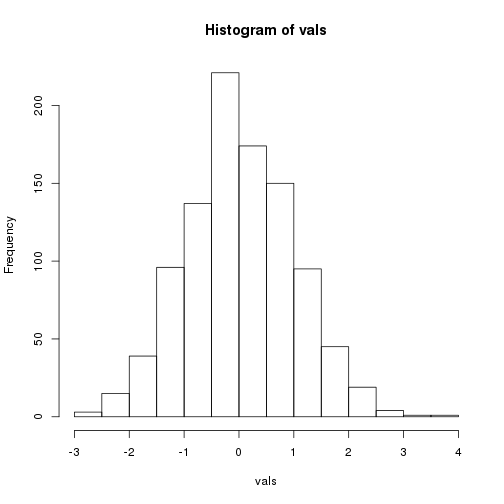

```r
histNormal <- function(N) {
  vals <- rnorm(N)
  hist(vals)
  invisible(max(vals))
}

histNormal(1000)
```

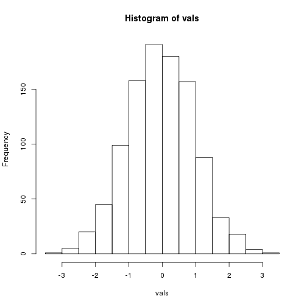

```r
max <- histNormal(1000)
```

```r
max
```

```
## [1] 3.028
```

# Functions with multiple arguments and default values

```r
newFunction <- function(num, threshold=0, modifier=2) {
  if (num < threshold) {
    return(num / modifier)
  } else {
    return(num * modifier)
  }
}
newFunction(2.6)
```

```
## [1] 5.2
```

R lazily matches arguments from left to right:

```r
newFunction(2.6, 3)
```

```
## [1] 1.3
```

```r
newFunction(2.6, 3, 1.3)
```

```
## [1] 2
```

But we can explicitly specify which argument is which:

```r
newFunction(2.6, modifier=1.3, threshold=3)
```

```
## [1] 2
```

And we can pass the other arguments to most pre-defined R functions:

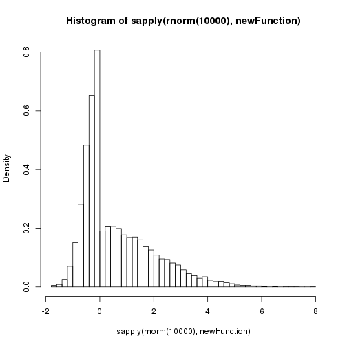

```r
hist(sapply(rnorm(10000), newFunction), breaks=60, freq=FALSE)
```

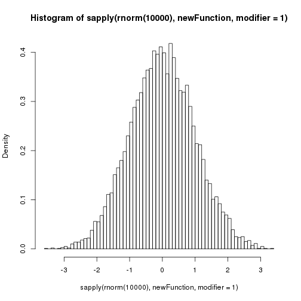

```r
hist(sapply(rnorm(10000), newFunction, modifier=1), breaks=60, freq=FALSE)
```

# What is the "..." argument for?

```r
args(hist)
```

```
## function (x, ...)
## NULL
```

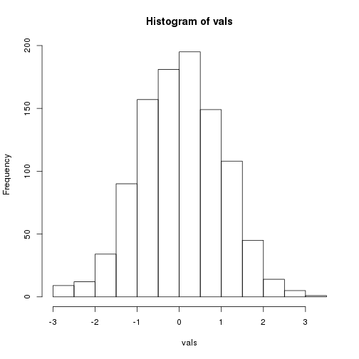

```r
histNormalWrapper <- function(N, ...) {
  vals <- rnorm(N)
  hist(vals, ...)
}

histNormalWrapper(1000)
```

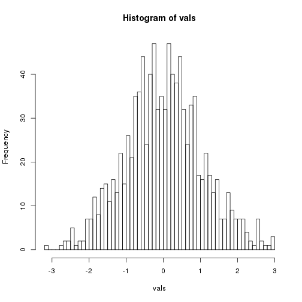

```r
histNormalWrapper(1000, breaks=50)
```

# Lazy evaluation

```r
colSorter <- function(data.matrix, col1, col2, col3) {
    ordered.idcs <- order(data.matrix[, col1], data.matrix[, col2], decreasing=TRUE)
    sorted.matrix <- data.matrix[ordered.idcs, ]
    return(sorted.matrix)
}

identical(earnings_ordered, colSorter(earnings, "earn", "height"))
```

```
## [1] TRUE
```

Even though we've called our function with an insufficient number of actual arguments to match our formal arguments, R doesn't complain. This is because R doesn't check to see if col3 has been associated with an object until R needs to retrieve the object. Since col3 isn't referenced in the body of the function, R never needs to retrieve its value and find that it can't.

Note that default arguments are lazily evaluated.

```r
f <- function(x=ls()) {
  a <- 1
  x
}
f()
```

```
## [1] "a" "x"
```

```r
f(ls())
```

```
##  [1] "a"                 "b"                 "colSorter"
##  [4] "e"                 "earnings"          "earnings_ordered"
##  [7] "f"                 "g"                 "histNormal"
## [10] "histNormalWrapper" "max"               "newFunction"
## [13] "ord"               "square"            "x"
```

# Control flow

More interesting when there is control flow:

- branching
- looping

# Branching: `if`-`else` statements

```r
val <- rnorm(1)
val
```

```
## [1] 0.4844
```

```r
if (val < 0) {
  "val is negative!"
} else {
  "val is positive"
}
```

```
## [1] "val is positive"
```

Chaining `if` statements:

```r
val <- rnorm(1)
val
```

```
## [1] 0.5839
```

```r
if (val < -1) {
  "val is more than one standard deviation below the mean."
} else if (abs(val) <= 1) {
  "val is within one standard deviation of the mean."
} else {
  "val is more than one standard deviation above the mean."
}
```

```
## [1] "val is within one standard deviation of the mean."
```

Zero evaluates to `FALSE`, all other numbers evaluate to `TRUE`. (And the string "true" evaluates to `TRUE` too... but not other strings.)

```r
val <- 3.1
if (val) {
  "3.1 is true?"
}
```

```
## [1] "3.1 is true?"
```

```r
if ("true") {
  "true is true?"
}
```

```
## [1] "true is true?"
```

```r
if ("bear") {
  "bear is true?"
}
```

```
## Error: argument is not interpretable as logical
```

# `for` loop

Abstract structure of `for loop`:

```r
for (variable in set) {
  statement
}
```

More concretely:

```r
myseq <- seq(5,20,by=5)
for (i in myseq) {
  print(i)
}
```

```
## [1] 5
## [1] 10
## [1] 15
## [1] 20
```

And more directly:

```r
for (i in seq(2,8, by=2)) {
  print(i)
}
```

```
## [1] 2
## [1] 4
## [1] 6
## [1] 8
```

But is it a function?

```r
'for'(i, seq(2,8, by=2), print(i))
```

```
## [1] 2
## [1] 4
## [1] 6
## [1] 8
```

# `while` loop

Abstractly:

```r
while (condition) {
  statements
}
```

Concretely:

```r
i <- 0
while (i < 10) {
  i <- i + 1
  print(i)
}
```

```
## [1] 1
## [1] 2
## [1] 3
## [1] 4
## [1] 5
## [1] 6
## [1] 7
## [1] 8
## [1] 9
## [1] 10
```

It's easy to create infinite loops!

# Examples: Fibonacci numbers

First 12 Fibonacci numbers:

```r
myseq[1] <- 0
myseq[2] <- 1
for (i in seq(3,12)) {
  myseq[i] <- myseq[i-2] + myseq[i-1]
}
myseq
```

```
##  [1]  0  1  1  2  3  5  8 13 21 34 55 89
```

Fibonacci numbers less than 500:

```r
myseq[1] <- 0
myseq[2] <- 1
i <- 2
currentVal <- 1
while (currentVal < 500) {
  myseq[i+1] <- currentVal
  currentVal <- myseq[i] + myseq[i+1]
  i = i+1
}
myseq
```

```
##  [1]   0   1   1   2   3   5   8  13  21  34  55  89 144 233 377
```

# Flow control: `next` and `break` statements

`next` skips the current evaluation of the loop statements:

```r
for (i in seq(1,10)) {
  if (i == 5) {
    next
  }
  print(i)
}
```

```
## [1] 1
## [1] 2
## [1] 3
## [1] 4
## [1] 6
## [1] 7
## [1] 8
## [1] 9
## [1] 10
```

`break` immediately ends loop evaluation:

```r
val <- 0
i <- 0
while(TRUE) {
  i <- i + 1
  val <- val + rnorm(1)
  if (abs(val) > 3) {
    break
  }
}
val
```

```
## [1] -3.224
```

```r
i
```

```
## [1] 12
```

# Avoid loops

Loops are frequently the wrong solution.

```r
vals <- rnorm(100)
maxVal <- vals[1]
for (val in vals) {
  if (val > maxVal) {
    maxVal = val
  }
}
maxVal
```

```
## [1] 2.548
```

Try to use builtin functions instead:

```r
max(vals)
```

```
## [1] 2.548
```

Operate directly on vectors rather than looping over them:

```r
myseq <- seq(2,20, by =2)
for(i in seq(1,10)) {
  myseq[i] <- myseq[i] + 2
}
myseq
```

```
##  [1]  4  6  8 10 12 14 16 18 20 22
```

```r
seq(2,20, by =2)+2
```

```
##  [1]  4  6  8 10 12 14 16 18 20 22
```

# Breakout (colSums 3 ways)

For this breakout, you will see how long it takes to compute the columns sums of a matrix in 3 different ways.

1. Create a function (rnormMatrix) that takes two arguments (r,c) and returns a rxc matrix of values drawn from a standard normal distribution.
2. Create a function (colSums.builtin) which takes a matrix and returns a vector of the column sums. Implement this function using R's builtin function colSums.
3. Create a function (colSums.apply) which takes a matrix and returns a vector of the column sums. Implement this function using R's builtin function sum and an apply statement.
4. Create a function (colSums.for) which takes a matrix and returns a vector of the column sums. Implement this function using R's builtin function sum and a for loop.
5. Create a few different sized matrices using rnormMatrix and see how long each of the colSums.xxx functions takes to compute the column sums. Compare the results from the different function calls to make sure you are computing the same result in each function.